# Homework-9

Alex Steiner

2024-03-27

Organizing Code With Structured Programming

1. Use the code that you worked on in Homework #7 (creating fake data sets), and re-organize it following the principles of structured programming. Do all the work in a single chunk in your R markdown file, just as if you were writing a single R script. Start with all of your annotated functions, preliminary calls, and global variables. The program body should be only a few lines of code that call the appropriate functions and run them in the correct order. Make sure that the output from one function serves as the input to the next. You can either daisy-chain the functions or write separate lines of code to hold elements in temporary variables and pass them along.

```r
# Generating fake data and putting it into a dataframe

dummy_organic <- function(nGroup = 3, nName = c("MirgExp","MirgCtrl", "Continuous"), nMean =c(6.334,5.834,4.104), nSize = 30, nSD = c(2.111,0.919,1.282), ID = 1:(sum(nSize= 90))) {
  organicmatter <- c(rnorm(n=30,mean=nMean[1],sd=nSD[1]),
            rnorm(n=30,mean=nMean[2],sd=nSD[2]),
            rnorm(n=30,mean=nMean[3],sd=nSD[3]))
  treatment <- rep(nName, nSize)
  datframe <- data.frame(ID,treatment,organicmatter)
}

a <- dummy_organic()
head(a)
```

```
##   ID  treatment organicmatter
## 1  1    MirgExp     9.4034795
## 2  2   MirgCtrl     7.1622554
## 3  3 Continuous     6.4212455
## 4  4    MirgExp     4.0584233
## 5  5   MirgCtrl    10.5585800
## 6  6 Continuous     0.9407937
```

4. Now write code to analyze the data (probably as an ANOVA or regression analysis, but possibly as a logistic regression or contingency table analysis. Write code to generate a useful graph of the data.

```r
anovadat <- function(x = a){
       anovarun <- aov(organicmatter~treatment, data = x)
  print(summary(anovarun))
}
b <- anovadat()
```

```
##             Df Sum Sq Mean Sq F value Pr(>F)
## treatment    2   17.1   8.544   2.101  0.128
## Residuals   87  353.7   4.066
```

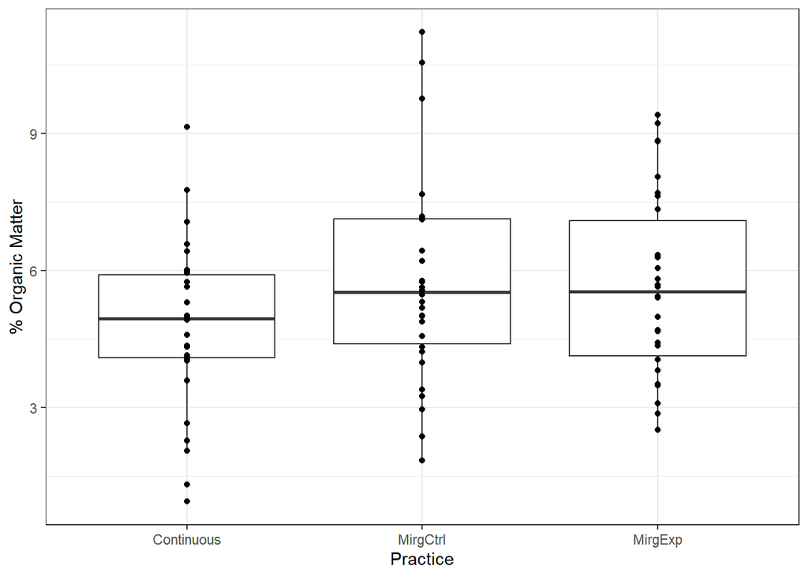

```r
##ggplot
library(ggplot2)
cbPalette <- c("#009E73","#CC79A7","#56B4E9")

plotfunc <- function(x = a){
  ggplot(data=a) +
  aes(x=treatment,y=organicmatter) +
  geom_boxplot()+
  scale_fill_manual(values=cbPalette)+
  labs(y = "% Organic Matter", x = "Practice")+
  geom_point()+
  theme_bw()

}
c <- plotfunc()
c
```

2. Once your code is up and working, modify your program to do something else: record a new summary variable, code a new statistical analysis, or create a different set of random variables or output graph. Do not rewrite any of your existing functions. Instead, copy them, rename them, and then modify them to do new things. Once your new functions are written, add some more lines of program code, calling a mixture of your previous functions and your new functions to get the job done.

```r
##Tukey function
tukeyfunc <- function(x = a){
  anovaout <- aov(organicmatter~treatment, data = x)
  tukey.test <- TukeyHSD(anovaout)
  print(tukey.test)
}
d <- tukeyfunc()
```

```
##   Tukey multiple comparisons of means
##     95% family-wise confidence level
##
## Fit: aov(formula = organicmatter ~ treatment, data = x)
##
## $treatment
##                            diff        lwr      upr     p adj
## MirgCtrl-Continuous  0.96690799 -0.2745276 2.208344 0.1574323
## MirgExp-Continuous   0.87486983 -0.3665657 2.116305 0.2184802
## MirgExp-MirgCtrl    -0.09203816 -1.3334737 1.149397 0.9829221
```